# Prosper Loan Data

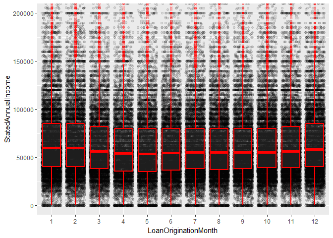

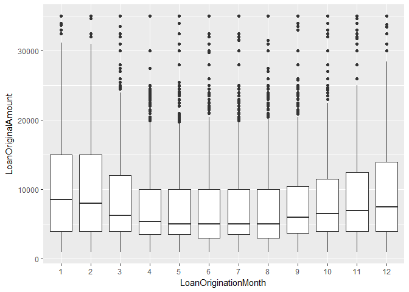

In the first plot, we can see that stated annual income and loan origination month are about the same throughout the year.

In the second plot, we can see that loan amounts are about the same from April to August. They start rising in September and are highest in January and February.

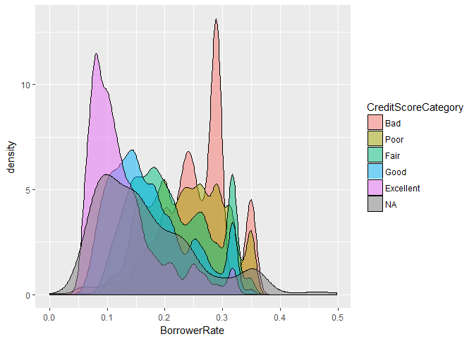

This plot shows a few noticeable peaks. The excellent credit score group has a high amount of borrowers with a low rate around 0.08. The bad credit score group has a high peak around 0.29, and a few smaller peaks at 0.24 and 0.35.

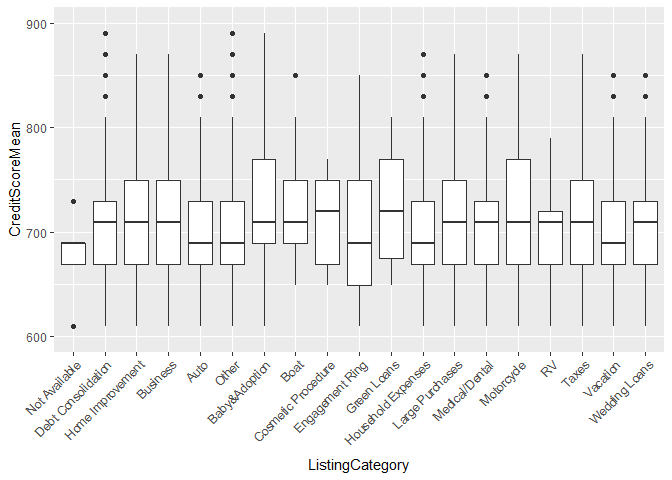

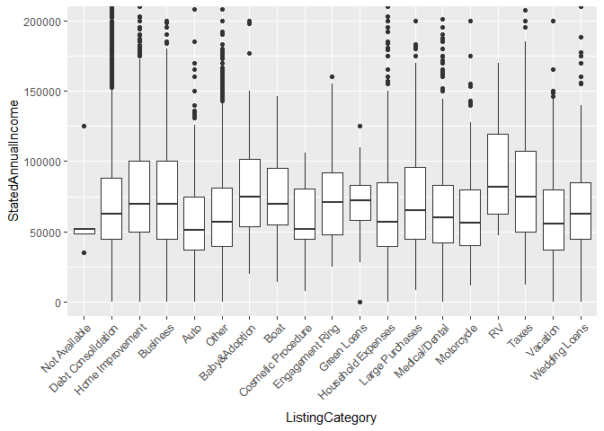

These two plots are using a subsetted version of the dataset which only includes loans started in 2013. In the first plot we can see that Green Loans have the highest median mean credit score. Some of the lowest median mean credit scores are for Auto, Other, Engagement Ring, Household Expenses, and Vacation.

The second plot shows that the highest median stated annual income is for the RV category, followed by Taxes and Baby&Adoption. Some of the lowest are Auto, Other, Cosmetic Procedure, Household Expenses, Motocycle, and Vacation.

# Bivariate Analysis

In this section, we’ve seen that there is a strong relationship between credit score category and borrower rate. We also saw that loans that were chargedoff, defaulted, or cancelled had borrowers with lower credit scores that other loan status groups. Another observation is that homeowners took out bigger loans than non-homeowners.

# Multivariate Plots

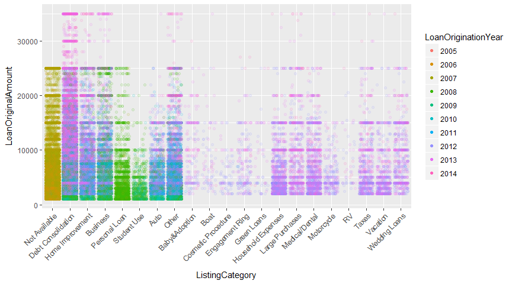

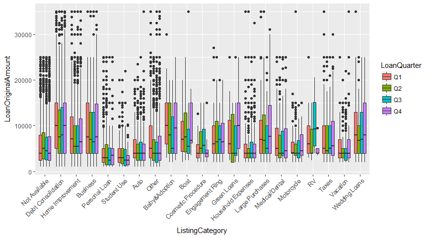

In the first plot we can see that the debt consolidation group has the most and highest amount of loans. In 2008 and 2009, there are a large number of personal loans and loans for student use. From 2012 on, there are a large number of loans in other categories, which could indicate that these categories were introduced at that time, and there may have been fewer listing categories available previously.

In the second plot, loan amount and listing category are shown by quarter. We can more clearly see the categories that have smaller loans on average. We can also see that some loan categories don’t have any loans higher than $25,000, which appeared to be the loan limit up until 2013. There’s a good chance that some of the categories that do not have loans over $25,000 were not part of the list of loan categories after 2012.

We’ve previously seen that debt consolidation is the largest loan category, and that the largest loans are taken out in the first and fourth quarter of the year. In this plot, we can see that the median loan for debt consolidation is around $10,000 in the first and fourth quarters, and observably lower in the second and third quarters. We see this same pattern in home improvement, business, wedding loans, baby and adoption. In green loans, we see a similar pattern, but with a distinct increase in the fourth quarter.

Let’s look at just 2013:

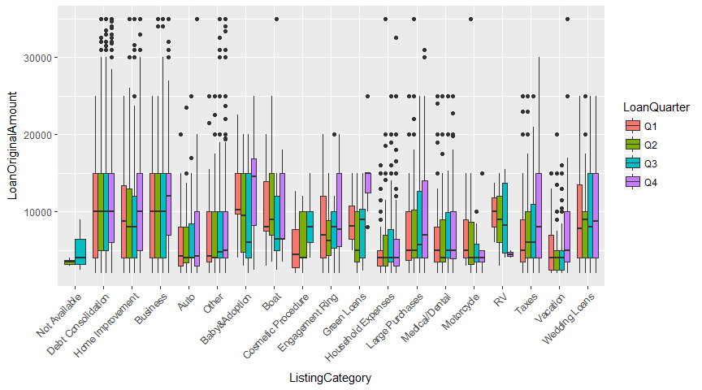

We can see that a couple of the categories are not present in this plot (Personal loan and Student Use), and there are fewer “Not Available”, so we can see loans broken down into more specific categories in this plot. It is interesting to see the different loan amounts per quarter for each category.

In this plot, the median loan amount for debt consolidation is the same throughout the year. Green loans continues its trend of having high loan original amounts in the fourth quarter.

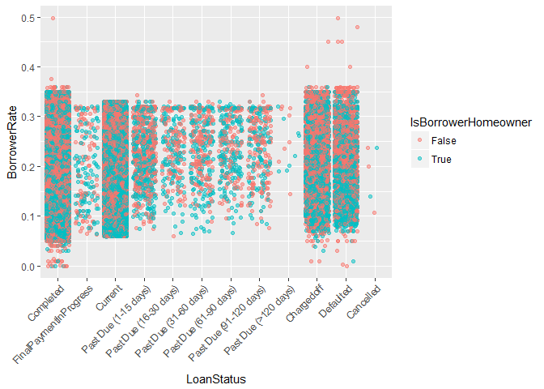

Overall, it appears homeowners have a lower borrower rate.

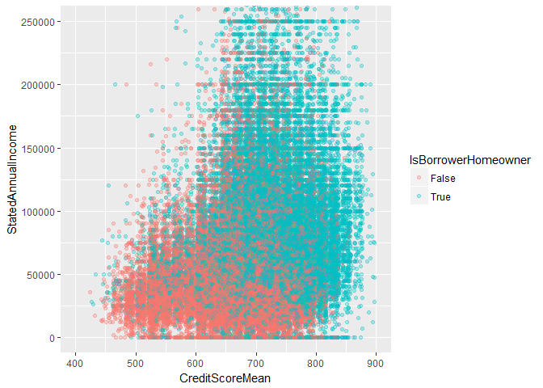

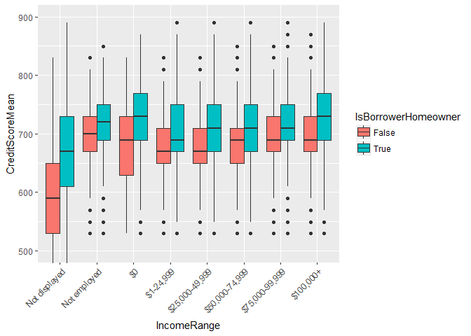

In the first plot, we can see that homeowners have higher credit scores and higher stated annual income. Borrowers with lower incomes and credit scores tend not to be homeowners.

In the second plot, we can more clearly see the disparity in median credit scores between homeowners and non homeowners.

If we test the correlation between just credit score mean and stated annual income, we see that there is not a linear relationship:

```
## [1] 0.1079008
```

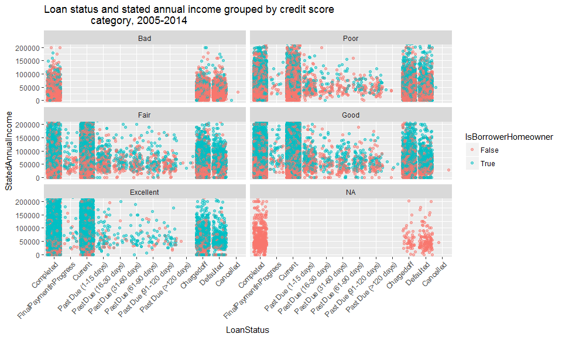

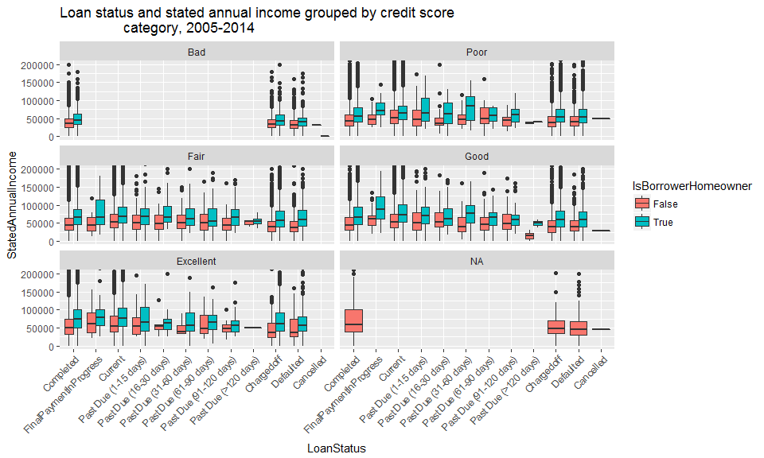

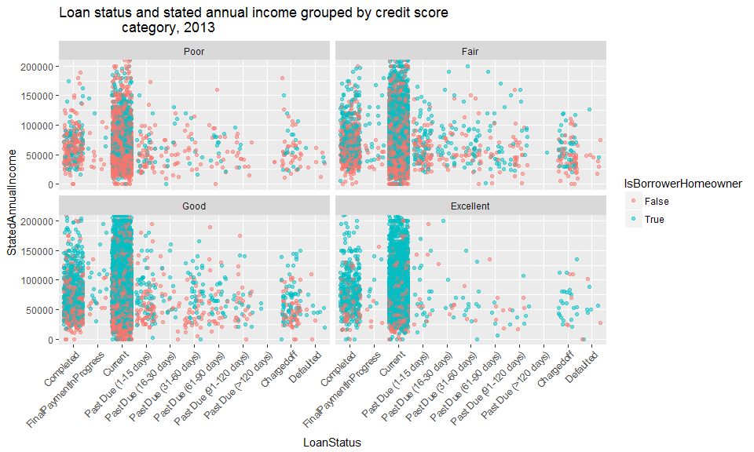

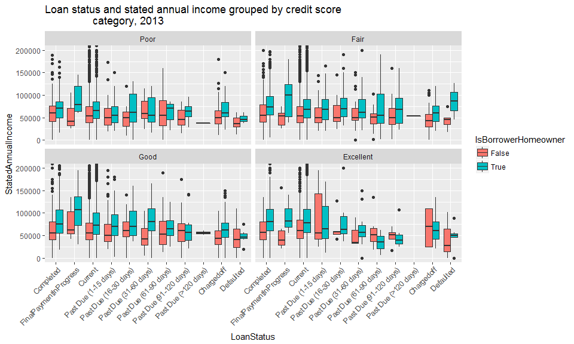

These plots show loan status and stated annual income grouped by credit score category and whether or not the borrower is a homeowner. The first two plots include the whole dataset, whereas the last two plots only show borrowers who started loans in 2013. One interesting difference is that the 2013 plots have two less credit score categories. The “Bad” and “NA” groups are not included. This could mean that Prosper no longer allows borrowers with bad credit or no credit to create loans, or that lenders chose not to lend to those groups. As observed earlier, homeowners tend to have higher credit scores. There is an observable low number of chargedoff and defaulted loans in the excellent credit score group in 2013, however, for all years there are a large number of chargedoff and defaulted loans in the excellent credit score group when we look at all years.

One interesting observation is that the median annual income for homeowners is almost always higher than non-homeowners. An exception is for chargedoff loans and loans 61-120 days past due for borrowers with Excellent credit in 2013. Another observation is homeowners with fair credit who defaulted on their loan have a relatively high median income.

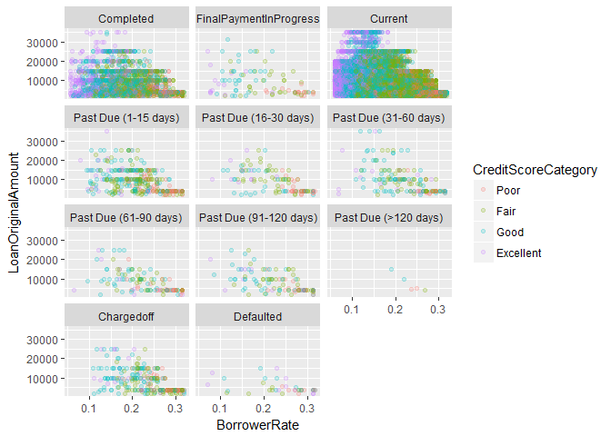

This plot looks at the borrower rate, original loan amount and credit score category, broken down by loan status for loans originating in 2013. We can see that borrowers with good credit have more loans for higher amounts and lower rates.

Let’s look at the correlation for borrower rate, original loan amoun, and credit score mean for loans overall, and in just 2013.

```
## [1] -0.3289599
```

```
## [1] -0.4071593
```

There is a weak negative linear relationship for borrower rate and loan original amount, but it is almost a moderate relationship in 2013.

```
## [1] 0.3408745
```

```
## [1] 0.2999042
```

We see a weak positive linear relationship for credit score mean and loan original amount, and it a little stronger overall than for just 2013.

```
## [1] -0.4615667
```

```
## [1] -0.5597953
```

Here we see a moderate negative linear relationship for credit score mean and borrower rate, with the relationship being stronger in 2013.

# Multivariate Analysis

In this section we saw that homeowners tend to have higher credit scores and stated annual income. I found it interesting that even borrowers with excellent credit scores had many defaulted and chargedoff loans.

# Final Plots and Summary

### Plot One

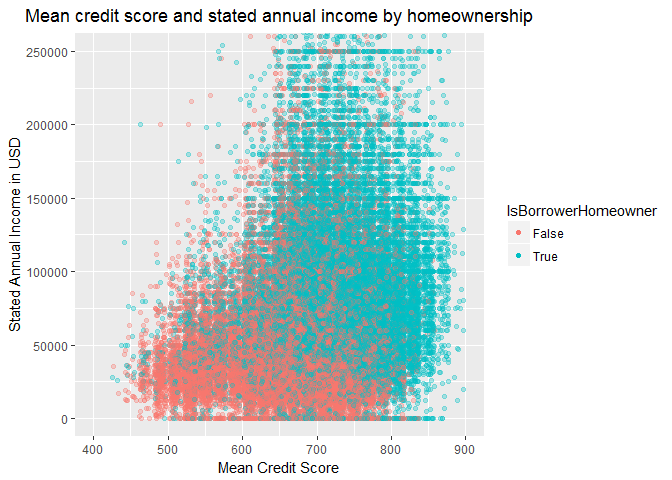

### Description One

This plot shows that homeowners tend to have higher incomes and credit scores. I chose this plot to feature because there is a distinct difference visible based on homeownership.

### Plot Two

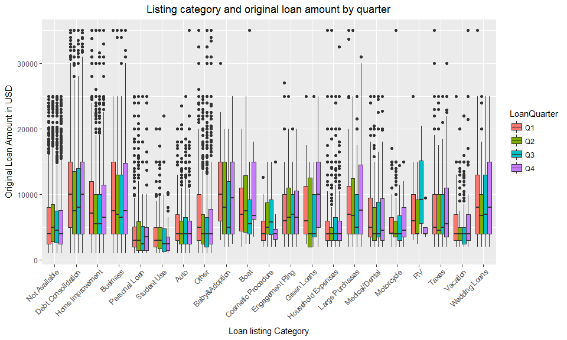

### Description Two

This plot shows a breakdown in loan categories by quarter. In previous plots, we saw that debt consolidation has the highest number of loans. We also saw that the most loans and the biggest loans are taken out in the first and fourth quarters. These observations are also reflected in this plot. I chose to include this plot because it’s easy to see how the range in loan amount and median loan amounts differ between categories and quarters.

### Plot Three

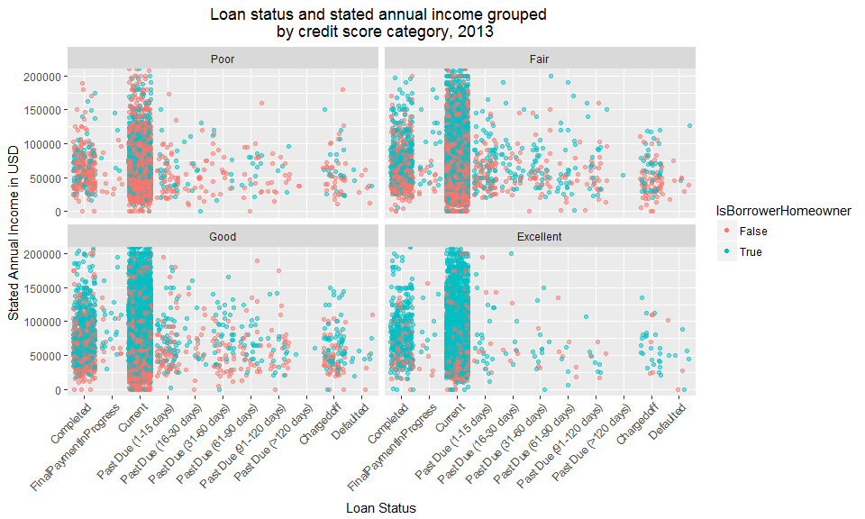

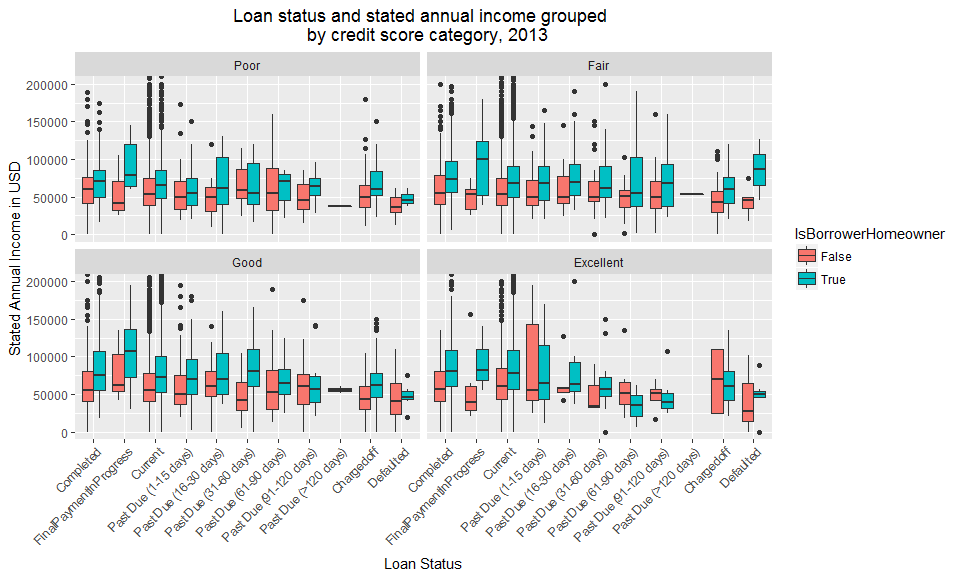

### Description Three

I chose to show this as both scatterplots and boxplots so that amount of loans as well as median and IQR could be displayed by homeownership. These charts reinforce that homeowners tend to have better credit as well as higher stated incomes. We can also see that they tend to have less chargedoff and defaulted loans. Thus we could conclude that homeowners with higher incomes are better loan candidates.

# Reflection

For me, a difficulty with a dataset of this size (number of variables and observations), was deciding which data to use and where to put my focus. As I began to explore the data, I began to find interesting patterns that warranted further exploration such as the high number of loans in 2013, and the patterns of homeownershp. I was able to find patterns in the data through visualizations.

For future work on this dataset, it would be interesting to explore the BorrowerState variable to see how the variables I’ve explored are related geographically.